# Correlation Heatmaps

##### Use an ExpressionSet object and add significance asterisks

The ExpressionSet object is created using the numeric data frame created above from the small TCGA dataset.

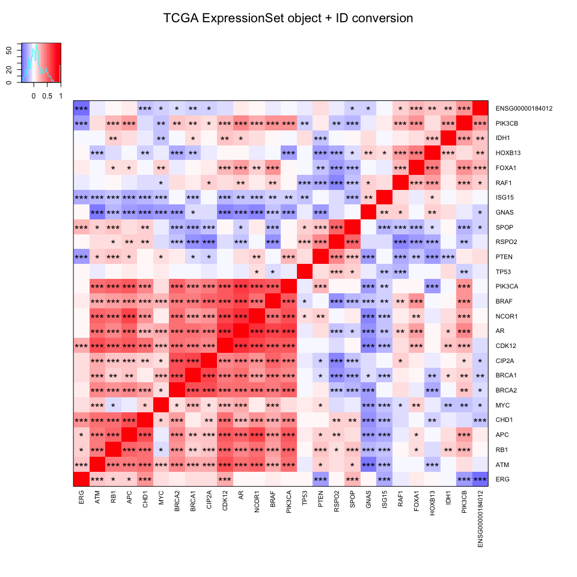

```r
## check for 'org.Hs.eg.db'
if (!requireNamespace("org.Hs.eg.db", quietly = TRUE)) {
  bm <- TRUE
} else {
  bm <- FALSE
}
expr <- Biobase::ExpressionSet(as.matrix(dat1))
cormap2(expr, add.sig=TRUE, autoadj=FALSE, cex=1, main="TCGA ExpressionSet object + ID conversion", biomart = bm, use.cache = FALSE)
```

#### Large dataset

500 genes were selected at random to demonstrate handling of larger datasets. We will first plot the entire matrix and then use the filtering capabilities of `cormap2` to identify possibly co-expressed genes. ##### Full map

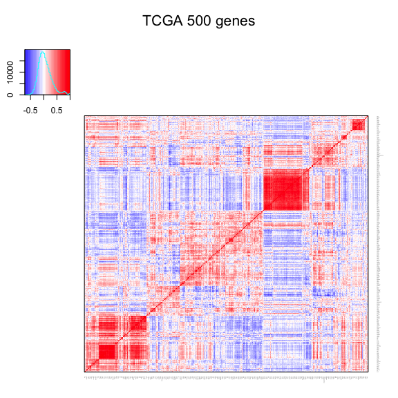

```r
fl <- system.file("extdata", "PrCaTCGASample_500.txt", package = "coreheat", mustWork = TRUE)
dat0_500 <- read.delim(fl, stringsAsFactors=FALSE)
dat1_500 <- data.frame(dat0_500[, grep("TCGA", names(dat0_500))], row.names=dat0_500$ensembl_gene_id)
cormap2(dat1_500, biomart = TRUE, use.cache = FALSE, main="TCGA 500 genes")
```

##### Filtering

###### Filter by tree branch height

Dendrogram branches are cut using function `cutreeStatic` from the `WGCNA` package. This will reduce the number of branches and, in consequence, the size of the correlation map, while retaining closely correlated values.  
Note that getting the values for `cut.thr` and `cut-size` right can take a bit trial and error.  
The number of rows left after filtering is added automatically if cutting is enabled. To remove that sub-title set `postfix` to `FALSE`.  
We also highlight a few genes that all appear to have a high correlation to see if we find them again in the next plot.

```r
cm <- cormap2(dat1_500, cut.thr = 1.5, cut.size = 40, biomart = TRUE, use.cache = FALSE,
              genes2highl = c("RPLP1", "NOP53", "RPL13", "RPS17", "RPL11", "RPS24", "RPL30", "EEF1D", "RPL27",
                              "SNHG29", "HSPA1A", "HSPA1B", "DNAJB1", "BHLHE40", "NR4A1", "JUND", "HLA-A", "HLA-B",
                              "BTF3", "EEF1A1P9"),
              main="TCGA 500 genes", verbose = TRUE)
```

```
#> @ Calculating correlation matrix...
#>   Computing correlations...
#>   Calculating P-Values...
#>    Getting NAs...
#>    Getting counts...
#>    Getting P-Values...
#> @ Clustering and filtering correlation matrix...
#> Input is a list with correlation matrix and pvalues. Assuming non-clustered matrix.
#> Filtering NAs...
#> Getting distance matrix and hierarchical clustering...
#> Cutting the dendrogram at 1.5...
#>   Isolated tree section with 185 genes
#>   Recalculating distance matrix and hierarchical clustering...
#> Ordering according to hierarchical clustering...
#> @ Formatting output matrix...
#>   Checking input IDs:
#>     Attempting to convert input matrix row names...
#> Getting CURL SSL options for securely contacting host 'https://www.ensembl.org'...
#> Using BioMart: 'ENSEMBL_MART_ENSEMBL'
#> Input ID type is 'ensembl_gene_id'
#>   Information requested: 'hgnc_symbol'...
#>     Merging input IDs and converted IDs...
#> done
#>     Replacing 2 missing Gene Symbol(s) by Ensembl IDs...
#> @ Generating heatmap...
#>   Ordering Y-axis...
```

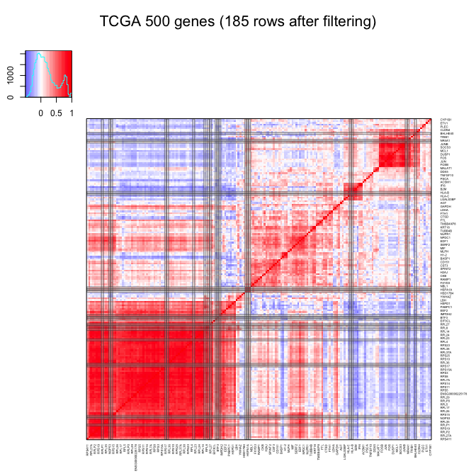

```r
cm2 <- cormap2(cormat = cm, cut.thr = 1.2, cut.size = 20, biomart = TRUE, use.cache = FALSE,
               genes2highl = c("RPLP1", "NOP53", "RPL13", "RPS17", "RPL11", "RPS24", "RPL30", "EEF1D", "RPL27",
                               "SNHG29", "HSPA1A", "HSPA1B", "DNAJB1", "BHLHE40", "NR4A1", "JUND", "HLA-A", "HLA-B",
                               "BTF3", "EEF1A1P9"),
               main="TCGA 500 genes", cex = 0.9, verbose = TRUE)
```

```
#> Input is a complete list with correlation matrix and P-Values.
#> @ Clustering and filtering correlation matrix...
#> Input is a list with correlation matrix and pvalues. Assuming non-clustered matrix.
#> Filtering NAs...
#> Getting distance matrix and hierarchical clustering...
#> Cutting the dendrogram at 1.2...
#>   Isolated tree section with 75 genes
#>   Recalculating distance matrix and hierarchical clustering...
#> Ordering according to hierarchical clustering...
#> @ Formatting output matrix...
#>   Checking input IDs:
#>     Attempting to convert input matrix row names...
#> Getting CURL SSL options for securely contacting host 'https://www.ensembl.org'...
#> Using BioMart: 'ENSEMBL_MART_ENSEMBL'
#> Input ID type is 'ensembl_gene_id'
#>   Information requested: 'hgnc_symbol'...
#>     Merging input IDs and converted IDs...
#> done
#>     Replacing 1 missing Gene Symbol(s) by Ensembl IDs...
#> @ Generating heatmap...
#>   Ordering Y-axis...
```

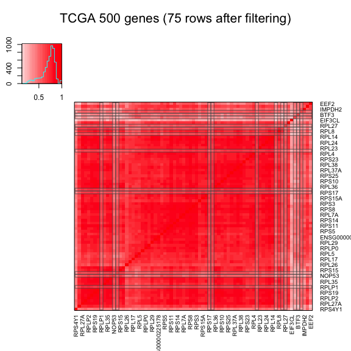

The genes we highlighted in the large map are found here, too. Filtering by branch height reduced the matrix further “picking” regions with similarly correlating values, in our case the bottom left block of positively correlated genes.

###### Filter by correlation threshold

But what if we want to filter for only highly correlating values? The package offers two approaches to pick “clusters” of values with a correlation above a certain threshold, a sliding window approach where the map is searched for the threshold and then the window is expanded as long as the threshold is met, and a simple margin approach where the threshold must be met in a given percentage of the rows.

**Sliding window** The user can set the size of the window, the correlation threshold and the “number” of the cluster to be picked. The cluster “number” here is a subjective value chosen after inspecting the source heatmap by eye and starting to count from the bottom left. For example, the first cluster with a correlation above 0.6 should give us the darker red block in the bottom left corner of the first map (object `cm`). Hence we set the window size to 5 and ask the function to highlight all the genes it finds from the same list as above. We add significance asterisks to see how good our correlation is.

```r
cm3 <- cormap2(cormat = cm, cor.thr = 0.6, cor.window = 5, cor.cluster = 1, biomart = TRUE, use.cache = FALSE,
               genes2highl = c("RPLP1", "NOP53", "RPL13", "RPS17", "RPL11", "RPS24", "RPL30", "EEF1D", "RPL27",
                               "SNHG29", "HSPA1A", "HSPA1B", "DNAJB1", "BHLHE40", "NR4A1", "JUND", "HLA-A", "HLA-B",
                               "BTF3", "EEF1A1P9"),
               add.sig = TRUE, cex = 2, main="TCGA 500 genes", verbose = TRUE)
```

```
#> Input is a complete list with correlation matrix and P-Values.
#> @ Clustering and filtering correlation matrix...
#> Input is a list with correlation matrix and pvalues. Assuming non-clustered matrix.
#> Filtering NAs...
#> Getting distance matrix and hierarchical clustering...
#> Ordering according to hierarchical clustering...
#> Filtering by correlation...
#>   Filtering by correlation threshold in a window of 5
#> Cycle 2  -> Found 1. cluster of correlating values (cor. threshold 0.6)
#>    -> Expanding window...
#>    -> done.
#> Filtered 170 rows not meeting correlation threshold (0.6 in 50% of the columns)
#> @ Formatting output matrix...
#>   Checking input IDs:
#>     Attempting to convert input matrix row names...
#> Getting CURL SSL options for securely contacting host 'https://www.ensembl.org'...
#> Using BioMart: 'ENSEMBL_MART_ENSEMBL'
#> Input ID type is 'ensembl_gene_id'
#>   Information requested: 'hgnc_symbol'...
#>     Merging input IDs and converted IDs...
#> done
#> @ Generating heatmap...
#>   Ordering Y-axis...
```

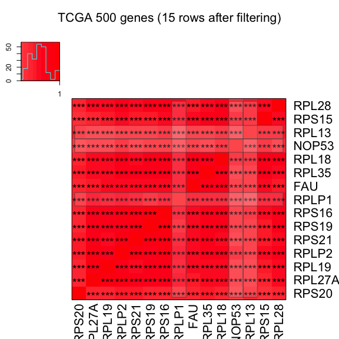

This approach picked the block we expected.

```r
cm3 <- cormap2(cormat = cm, cor.thr = 0.6, cor.mar = 0.3, biomart = TRUE, use.cache = FALSE,
               genes2highl = c("RPLP1", "NOP53", "RPL13", "RPS17", "RPL11", "RPS24", "RPL30", "EEF1D", "RPL27",
                               "SNHG29", "HSPA1A", "HSPA1B", "DNAJB1", "BHLHE40", "NR4A1", "JUND", "HLA-A",
                               "HLA-B"),
               main="TCGA 500 genes", cex = 1, verbose = T)
```

```
#> Input is a complete list with correlation matrix and P-Values.
#> @ Clustering and filtering correlation matrix...
#> Input is a list with correlation matrix and pvalues. Assuming non-clustered matrix.
#> Filtering NAs...
#> Getting distance matrix and hierarchical clustering...
#> Ordering according to hierarchical clustering...
#> Filtering by correlation...
#>   Filtering by correlation threshold with a margin of 30%
#> Filtered 120 rows not meeting correlation threshold (0.6 in 30% of the columns)
#> @ Formatting output matrix...
#>   Checking input IDs:
#>     Attempting to convert input matrix row names...
#> Getting CURL SSL options for securely contacting host 'https://www.ensembl.org'...
#> Using BioMart: 'ENSEMBL_MART_ENSEMBL'
#> Input ID type is 'ensembl_gene_id'
#>   Information requested: 'hgnc_symbol'...
#>     Merging input IDs and converted IDs...
#> done
#>     Replacing 1 missing Gene Symbol(s) by Ensembl IDs...
#> @ Generating heatmap...
#>   Ordering Y-axis...
```

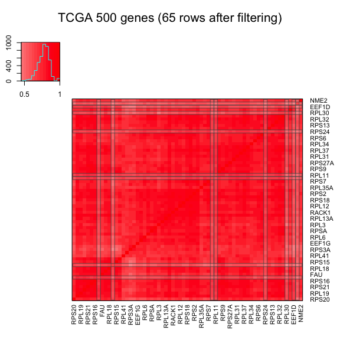

This also extracted a region from the positively correlated region at the bottom left of the original matrix but only the genes correlating above the threshold.

**Negative correlation** Since there are less and less extreme negative correlations in the matrix we have to set the thresholds to very lax values.

```r
## check for 'org.Hs.eg.db'
if (!requireNamespace("org.Hs.eg.db", quietly = TRUE)) {
  bm <- TRUE
} else {
  bm <- FALSE
}
cm3 <- cormap2(cormat = cm, cor.thr = -0.2, cor.mar = 0.2, biomart = bm, use.cache = FALSE,
               genes2highl = c("RPLP1", "NOP53", "RPL13", "RPS17", "RPL11", "RPS24", "RPL30", "EEF1D", "RPL27",
                               "SNHG29", "HSPA1A", "HSPA1B", "DNAJB1", "BHLHE40", "NR4A1", "JUND", "HLA-A",
                               "HLA-B"),
               add.sig = TRUE, cex = 2, main="TCGA 500 genes")
```

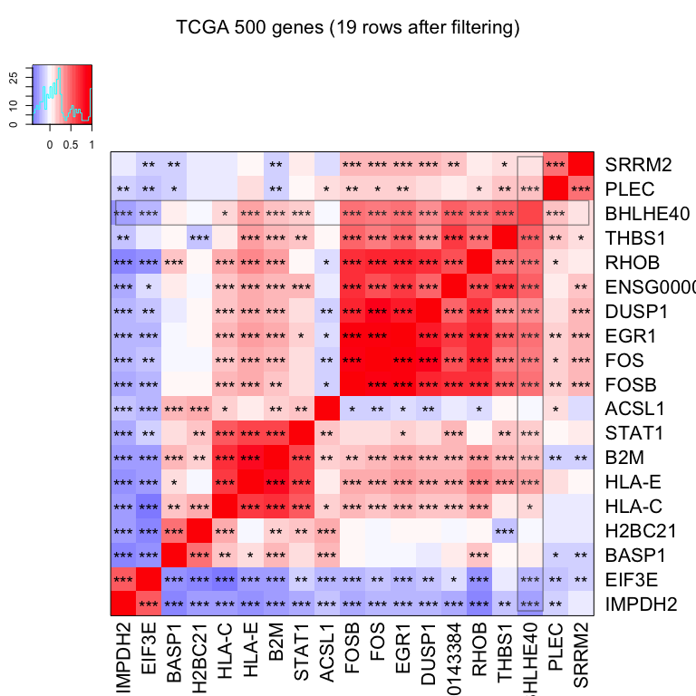

###### Filter by noise level and hierarchy

The function `cormap_filt` splits (cuts) a dendrogram of a hierarchically clustered distance matrix at a given threshold dividing it into larger or smaller “sub-clusters”. Correlation P-Values are converted to represent significance as a sub-cluster-wise signal metric used for filtering. Optionally, up to 3 plots are produced, the third one being a filtered heatmap based on significance and three height cutting.  
`cormap_filt` is a convenience function that accepts an ExpressionSet, a data frame or a numeric matrix as input. Note, that it will not work on a correlation matrix, as it needs the P-Values calculated internally for filtering.

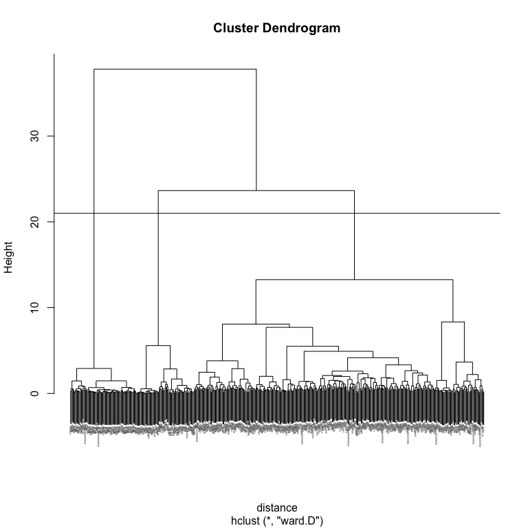

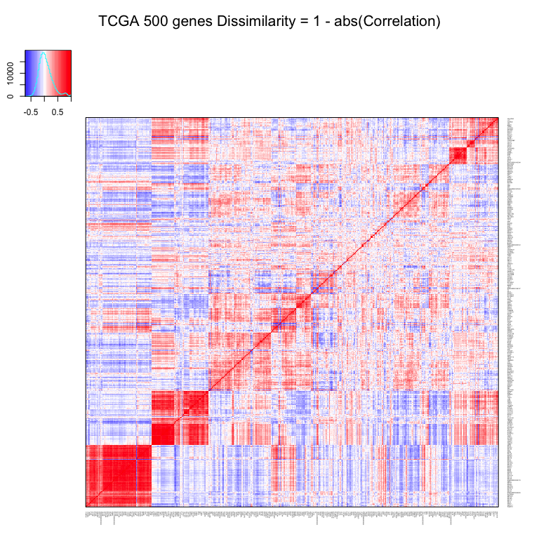

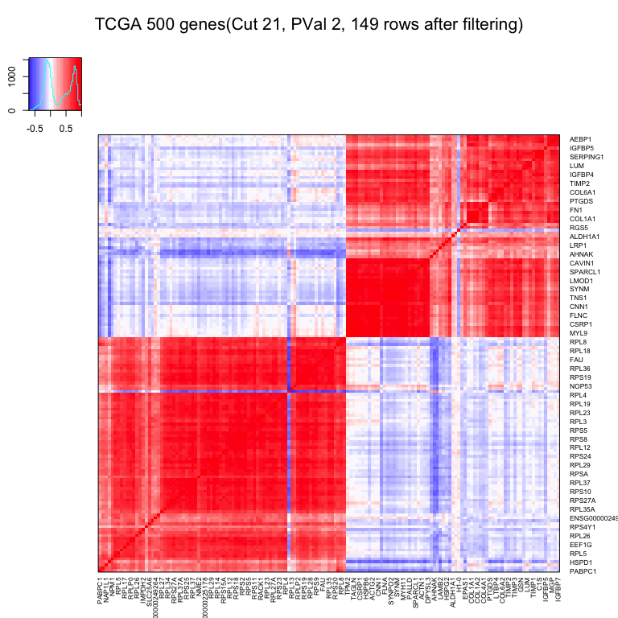

```r
## check for 'org.Hs.eg.db'
if (!requireNamespace("org.Hs.eg.db", quietly = TRUE)) {
  bm <- TRUE
} else {
  bm <- FALSE
}
cormap_filt(dat1_500, main = "TCGA 500 genes", cut.thr = 21, p.thr = 0.01, cex.filt = 0.8, biomart = bm, use.cache = FALSE)
```